# Danish Kings

Anonymous

2026-12-03

## Load dataset

```r
library(tidyverse)
monarchs <- read_csv2("data/Danish Monarchs.csv")
```

```
## ℹ Using "','" as decimal and "'.'" as grouping mark. Use `read_delim()` for more control.
```

## Explore the dataset

I explore the dataset to get an overview of its content

glimpse() shows the dataset structure, including the column names.

```r
glimpse(monarchs)
```

```
## Rows: 54
## Columns: 6
## $ Navn           <chr> "Gorm_den_Gamle", "Harald_Blaatand", "Svend_Tveskaeg", …
## $ Fødselsaar     <dbl> 900, 932, 960, 996, 995, 1018, 1019, 1024, 1040, 1042, …
## $ Dødsaar        <dbl> 958, 985, 1014, 1018, 1035, 1042, 1076, 1047, 1080, 108…
## $ Regeringsstart <dbl> 936, 958, 987, 1014, 1018, 1035, 1047, 1042, 1076, 1080…
## $ Regeringsslut  <dbl> 958, 987, 1014, 1018, 1035, 1042, 1076, 1047, 1080, 108…
## $ Kommentar      <dbl> 2, 1, 1, 1, 1, NA, 1, 1, 1, 1, 1, 1, 1, 1, 1, 3, 3, 3, …
```

head() displays the first six rows of the dataset

```r
head(monarchs)
```

```
## # A tibble: 6 × 6
##   Navn            Fødselsaar Dødsaar Regeringsstart Regeringsslut Kommentar
##   <chr>                <dbl>   <dbl>          <dbl>         <dbl>     <dbl>
## 1 Gorm_den_Gamle         900     958            936           958         2
## 2 Harald_Blaatand        932     985            958           987         1
## 3 Svend_Tveskaeg         960    1014            987          1014         1
## 4 Harald_2               996    1018           1014          1018         1
## 5 Knud_den_Store         995    1035           1018          1035         1
## 6 Hardeknud             1018    1042           1035          1042        NA
```

These functions help check the dataset is loaded correctly and if it is ready for an analysis.

## Average reign length

This code calculates the average reign lenth of the Danish monarchs. It creates a new column with the lennth of each reign, then calculates the average while ignoring missing values. Lastly, it identifies the monarchs who ruled longer than the average and prints the average reign lenth and the number of rulers above the average.

```r
monarchs <- monarchs %>%
  mutate(reign_length = Regeringsslut - Regeringsstart)

average_reign <- mean(monarchs$reign_length, na.rm = TRUE)

above_average <- monarchs %>%
  filter(reign_length > average_reign)


cat("Average reign length:", average_reign, "years\n")
```

```
## Average reign length: 20.79245 years
```

```r
cat("Number of rulers above average:", nrow(above_average))
```

```
## Number of rulers above average: 26
```

## Longest reigns among the monarchs

This code finds the three monarchs with the longest reigns. It calculates the length of each reign in years and days, then sorts the monarchs from longest to shortest reign. Finally, it displays the names and reign lengths of the top three monarchs.

```r
longest_monarchs <- monarchs %>%
  mutate(
    reign_length = Regeringsslut - Regeringsstart,
    reign_days = reign_length * 365
  ) %>%
  arrange(desc(reign_length)) %>%
  slice(1:3)

longest_monarchs %>%
  select(Navn, reign_length, reign_days)
```

```
## # A tibble: 3 × 3
##   Navn        reign_length reign_days
##   <chr>              <dbl>      <dbl>
## 1 Christian_4           60      21900
## 2 Margrethe_2           52      18980
## 3 Christian_9           43      15695
```

## Three longest-ruling monarchs

This code finds the three longest-ruling monarchs. It calculates the length of each reign, sorts the monarchs from longest to shortest reign, and selects the top three, so it can display the names of the monarchs and their reign lengths.

```r
longest_monarchs <- monarchs %>%
  mutate(
    reign_length = Regeringsslut - Regeringsstart
  ) %>%
  arrange(desc(reign_length)) %>%
  slice(1:3)

longest_monarchs %>%
  select(Navn, reign_length)
```

```
## # A tibble: 3 × 2
##   Navn        reign_length
##   <chr>              <dbl>
## 1 Christian_4           60
## 2 Margrethe_2           52
## 3 Christian_9           43
```

## Reign length over time

This code creates a plot showing how the reign lengths of Danish monarchs have changed over time. It calculates the length and midpoint of each reign, then plots the data ad points with a trend line. The gragh makes it easier to identify overall patterns in reign lenth over time.

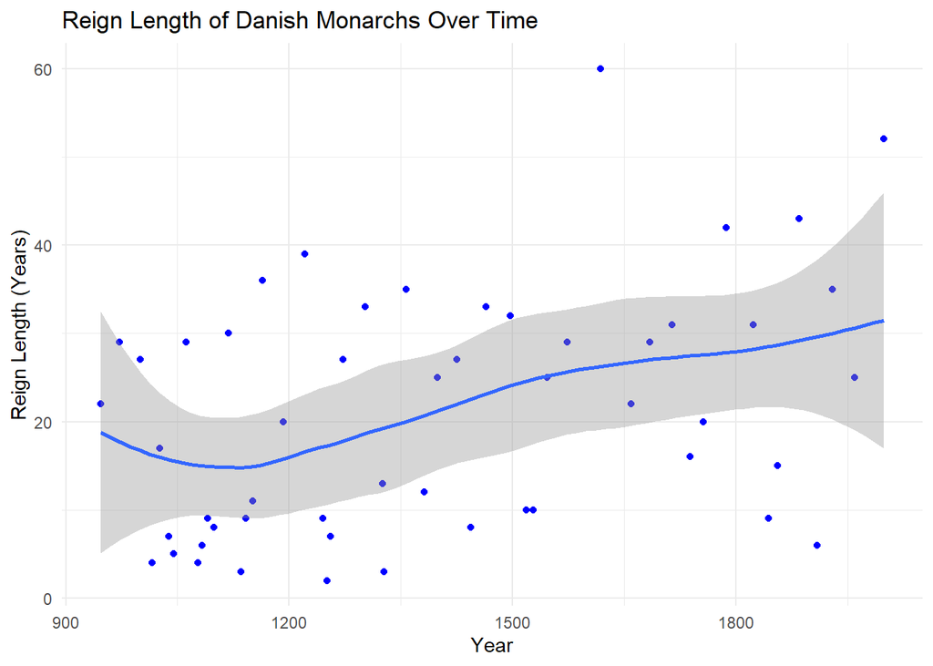

```r
monarchs_plot <- monarchs %>%
  mutate(
    reign_length = Regeringsslut - Regeringsstart,
    mid_year = (Regeringsstart + Regeringsslut) / 2
  )

ggplot(monarchs_plot, aes(x = mid_year, y = reign_length)) +
  geom_point(color = "blue") +
  geom_smooth() +
  theme_minimal() +
  labs(
    title = "Reign Length of Danish Monarchs Over Time",
    x = "Year",
    y = "Reign Length (Years)"
  )
```